# Risk Factor Analysis

## Outcome Variable

**Outcome Variable:** stunted

## Predictor Variables

**Intervention Variable:** tr

**Adjustment Set:**

unadjusted

## Stratifying Variables

The analysis was stratified on these variable(s):

- mwtkg
- agecat
- studyid
- country

## Data Summary

| mwtkg | agecat | studyid | country | tr | stunted | n_cell | n |
| --- | --- | --- | --- | --- | --- | --- | --- |
| >=57.5 | 24 months | ki1000110-WASH-Bangladesh | BANGLADESH | Control | 0 | 20 | 111 |
| >=57.5 | 24 months | ki1000110-WASH-Bangladesh | BANGLADESH | Control | 1 | 5 | 111 |
| >=57.5 | 24 months | ki1000110-WASH-Bangladesh | BANGLADESH | LNS | 0 | 26 | 111 |
| >=57.5 | 24 months | ki1000110-WASH-Bangladesh | BANGLADESH | LNS | 1 | 6 | 111 |
| >=57.5 | 24 months | ki1000110-WASH-Bangladesh | BANGLADESH | Other | 0 | 44 | 111 |
| >=57.5 | 24 months | ki1000110-WASH-Bangladesh | BANGLADESH | Other | 1 | 10 | 111 |
| <42.5 | 24 months | ki1000110-WASH-Bangladesh | BANGLADESH | Control | 0 | 45 | 443 |
| <42.5 | 24 months | ki1000110-WASH-Bangladesh | BANGLADESH | Control | 1 | 57 | 443 |
| <42.5 | 24 months | ki1000110-WASH-Bangladesh | BANGLADESH | LNS | 0 | 63 | 443 |
| <42.5 | 24 months | ki1000110-WASH-Bangladesh | BANGLADESH | LNS | 1 | 54 | 443 |
| <42.5 | 24 months | ki1000110-WASH-Bangladesh | BANGLADESH | Other | 0 | 102 | 443 |
| <42.5 | 24 months | ki1000110-WASH-Bangladesh | BANGLADESH | Other | 1 | 122 | 443 |
| [50-57.5) | 24 months | ki1000110-WASH-Bangladesh | BANGLADESH | Control | 0 | 30 | 200 |
| [50-57.5) | 24 months | ki1000110-WASH-Bangladesh | BANGLADESH | Control | 1 | 13 | 200 |
| [50-57.5) | 24 months | ki1000110-WASH-Bangladesh | BANGLADESH | LNS | 0 | 44 | 200 |
| [50-57.5) | 24 months | ki1000110-WASH-Bangladesh | BANGLADESH | LNS | 1 | 14 | 200 |
| [50-57.5) | 24 months | ki1000110-WASH-Bangladesh | BANGLADESH | Other | 0 | 70 | 200 |
| [50-57.5) | 24 months | ki1000110-WASH-Bangladesh | BANGLADESH | Other | 1 | 29 | 200 |
| [42.5-50) | 24 months | ki1000110-WASH-Bangladesh | BANGLADESH | Control | 0 | 61 | 433 |
| [42.5-50) | 24 months | ki1000110-WASH-Bangladesh | BANGLADESH | Control | 1 | 40 | 433 |
| [42.5-50) | 24 months | ki1000110-WASH-Bangladesh | BANGLADESH | LNS | 0 | 58 | 433 |
| [42.5-50) | 24 months | ki1000110-WASH-Bangladesh | BANGLADESH | LNS | 1 | 42 | 433 |
| [42.5-50) | 24 months | ki1000110-WASH-Bangladesh | BANGLADESH | Other | 0 | 141 | 433 |
| [42.5-50) | 24 months | ki1000110-WASH-Bangladesh | BANGLADESH | Other | 1 | 91 | 433 |
| <42.5 | 6 months | ki1000110-WASH-Bangladesh | BANGLADESH | Control | 0 | 47 | 255 |
| <42.5 | 6 months | ki1000110-WASH-Bangladesh | BANGLADESH | Control | 1 | 17 | 255 |
| <42.5 | 6 months | ki1000110-WASH-Bangladesh | BANGLADESH | LNS | 0 | 57 | 255 |
| <42.5 | 6 months | ki1000110-WASH-Bangladesh | BANGLADESH | LNS | 1 | 20 | 255 |
| <42.5 | 6 months | ki1000110-WASH-Bangladesh | BANGLADESH | Other | 0 | 89 | 255 |
| <42.5 | 6 months | ki1000110-WASH-Bangladesh | BANGLADESH | Other | 1 | 25 | 255 |

[output cut: 358 more lines]

The following strata were considered:

- mwtkg: [42.5-50), agecat: 24 months, studyid: iLiNS_DYADM_LNS, country: MALAWI
- mwtkg: [42.5-50), agecat: 24 months, studyid: ki1000110-WASH-Bangladesh, country: BANGLADESH
- mwtkg: [42.5-50), agecat: 24 months, studyid: ki1017093b-PROVIDE, country: BANGLADESH
- mwtkg: [42.5-50), agecat: 24 months, studyid: ki1066203-TanzaniaChild2, country: TANZANIA, UNITED REPUBLIC OF
- mwtkg: [42.5-50), agecat: 24 months, studyid: ki1112895-Burkina Faso Zn, country: BURKINA FASO
- mwtkg: [42.5-50), agecat: 24 months, studyid: ki1119695-PROBIT, country: BELARUS
- mwtkg: [42.5-50), agecat: 24 months, studyid: ki1126311-ZVITAMBO, country: ZIMBABWE
- mwtkg: [42.5-50), agecat: 24 months, studyid: ki1148112-iLiNS-DOSE, country: MALAWI
- mwtkg: [42.5-50), agecat: 24 months, studyid: ki1148112-iLiNS-DYAD-M, country: MALAWI
- mwtkg: [42.5-50), agecat: 24 months, studyid: ki1148112-LCNI-5, country: MALAWI
- mwtkg: [42.5-50), agecat: 6 months, studyid: iLiNS_DYADM_LNS, country: MALAWI
- mwtkg: [42.5-50), agecat: 6 months, studyid: ki1000110-WASH-Bangladesh, country: BANGLADESH
- mwtkg: [42.5-50), agecat: 6 months, studyid: ki1000125-AgaKhanUniv, country: PAKISTAN
- mwtkg: [42.5-50), agecat: 6 months, studyid: ki1000304b-SAS-CompFeed, country: INDIA
- mwtkg: [42.5-50), agecat: 6 months, studyid: ki1017093b-PROVIDE, country: BANGLADESH
- mwtkg: [42.5-50), agecat: 6 months, studyid: ki1066203-TanzaniaChild2, country: TANZANIA, UNITED REPUBLIC OF
- mwtkg: [42.5-50), agecat: 6 months, studyid: ki1112895-Burkina Faso Zn, country: BURKINA FASO
- mwtkg: [42.5-50), agecat: 6 months, studyid: ki1119695-PROBIT, country: BELARUS
- mwtkg: [42.5-50), agecat: 6 months, studyid: ki1126311-ZVITAMBO, country: ZIMBABWE
- mwtkg: [42.5-50), agecat: 6 months, studyid: ki1148112-iLiNS-DOSE, country: MALAWI
- mwtkg: [42.5-50), agecat: 6 months, studyid: ki1148112-iLiNS-DYAD-M, country: MALAWI
- mwtkg: [42.5-50), agecat: 6 months, studyid: ki1148112-LCNI-5, country: MALAWI
- mwtkg: [42.5-50), agecat: Birth, studyid: ki1000125-AgaKhanUniv, country: PAKISTAN
- mwtkg: [42.5-50), agecat: Birth, studyid: ki1000304b-SAS-CompFeed, country: INDIA
- mwtkg: [42.5-50), agecat: Birth, studyid: ki1119695-PROBIT, country: BELARUS
- mwtkg: [42.5-50), agecat: Birth, studyid: ki1126311-ZVITAMBO, country: ZIMBABWE
- mwtkg: [50-57.5), agecat: 24 months, studyid: iLiNS_DYADM_LNS, country: MALAWI
- mwtkg: [50-57.5), agecat: 24 months, studyid: ki1000110-WASH-Bangladesh, country: BANGLADESH
- mwtkg: [50-57.5), agecat: 24 months, studyid: ki1066203-TanzaniaChild2, country: TANZANIA, UNITED REPUBLIC OF
- mwtkg: [50-57.5), agecat: 24 months, studyid: ki1112895-Burkina Faso Zn, country: BURKINA FASO
- mwtkg: [50-57.5), agecat: 24 months, studyid: ki1119695-PROBIT, country: BELARUS
- mwtkg: [50-57.5), agecat: 24 months, studyid: ki1126311-ZVITAMBO, country: ZIMBABWE
- mwtkg: [50-57.5), agecat: 24 months, studyid: ki1148112-iLiNS-DOSE, country: MALAWI
- mwtkg: [50-57.5), agecat: 24 months, studyid: ki1148112-iLiNS-DYAD-M, country: MALAWI
- mwtkg: [50-57.5), agecat: 24 months, studyid: ki1148112-LCNI-5, country: MALAWI
- mwtkg: [50-57.5), agecat: 6 months, studyid: iLiNS_DYADM_LNS, country: MALAWI
- mwtkg: [50-57.5), agecat: 6 months, studyid: ki1000110-WASH-Bangladesh, country: BANGLADESH
- mwtkg: [50-57.5), agecat: 6 months, studyid: ki1000125-AgaKhanUniv, country: PAKISTAN
- mwtkg: [50-57.5), agecat: 6 months, studyid: ki1000304b-SAS-CompFeed, country: INDIA
- mwtkg: [50-57.5), agecat: 6 months, studyid: ki1017093b-PROVIDE, country: BANGLADESH
- mwtkg: [50-57.5), agecat: 6 months, studyid: ki1066203-TanzaniaChild2, country: TANZANIA, UNITED REPUBLIC OF
- mwtkg: [50-57.5), agecat: 6 months, studyid: ki1112895-Burkina Faso Zn, country: BURKINA FASO
- mwtkg: [50-57.5), agecat: 6 months, studyid: ki1119695-PROBIT, country: BELARUS
- mwtkg: [50-57.5), agecat: 6 months, studyid: ki1126311-ZVITAMBO, country: ZIMBABWE
- mwtkg: [50-57.5), agecat: 6 months, studyid: ki1148112-iLiNS-DOSE, country: MALAWI
- mwtkg: [50-57.5), agecat: 6 months, studyid: ki1148112-iLiNS-DYAD-M, country: MALAWI
- mwtkg: [50-57.5), agecat: 6 months, studyid: ki1148112-LCNI-5, country: MALAWI
- mwtkg: [50-57.5), agecat: Birth, studyid: ki1000125-AgaKhanUniv, country: PAKISTAN
- mwtkg: [50-57.5), agecat: Birth, studyid: ki1000304b-SAS-CompFeed, country: INDIA
- mwtkg: [50-57.5), agecat: Birth, studyid: ki1119695-PROBIT, country: BELARUS
- mwtkg: [50-57.5), agecat: Birth, studyid: ki1126311-ZVITAMBO, country: ZIMBABWE
- mwtkg: <42.5, agecat: 24 months, studyid: iLiNS_DYADM_LNS, country: MALAWI
- mwtkg: <42.5, agecat: 24 months, studyid: ki1000110-WASH-Bangladesh, country: BANGLADESH
- mwtkg: <42.5, agecat: 24 months, studyid: ki1112895-Burkina Faso Zn, country: BURKINA FASO
- mwtkg: <42.5, agecat: 24 months, studyid: ki1119695-PROBIT, country: BELARUS
- mwtkg: <42.5, agecat: 24 months, studyid: ki1126311-ZVITAMBO, country: ZIMBABWE
- mwtkg: <42.5, agecat: 24 months, studyid: ki1148112-iLiNS-DOSE, country: MALAWI
- mwtkg: <42.5, agecat: 24 months, studyid: ki1148112-iLiNS-DYAD-M, country: MALAWI
- mwtkg: <42.5, agecat: 24 months, studyid: ki1148112-LCNI-5, country: MALAWI
- mwtkg: <42.5, agecat: 6 months, studyid: iLiNS_DYADM_LNS, country: MALAWI
- mwtkg: <42.5, agecat: 6 months, studyid: ki1000110-WASH-Bangladesh, country: BANGLADESH
- mwtkg: <42.5, agecat: 6 months, studyid: ki1000125-AgaKhanUniv, country: PAKISTAN
- mwtkg: <42.5, agecat: 6 months, studyid: ki1000304b-SAS-CompFeed, country: INDIA
- mwtkg: <42.5, agecat: 6 months, studyid: ki1017093b-PROVIDE, country: BANGLADESH
- mwtkg: <42.5, agecat: 6 months, studyid: ki1066203-TanzaniaChild2, country: TANZANIA, UNITED REPUBLIC OF
- mwtkg: <42.5, agecat: 6 months, studyid: ki1112895-Burkina Faso Zn, country: BURKINA FASO
- mwtkg: <42.5, agecat: 6 months, studyid: ki1119695-PROBIT, country: BELARUS
- mwtkg: <42.5, agecat: 6 months, studyid: ki1126311-ZVITAMBO, country: ZIMBABWE
- mwtkg: <42.5, agecat: 6 months, studyid: ki1148112-iLiNS-DOSE, country: MALAWI
- mwtkg: <42.5, agecat: 6 months, studyid: ki1148112-iLiNS-DYAD-M, country: MALAWI
- mwtkg: <42.5, agecat: 6 months, studyid: ki1148112-LCNI-5, country: MALAWI
- mwtkg: <42.5, agecat: Birth, studyid: iLiNS_DYADM_LNS, country: MALAWI
- mwtkg: <42.5, agecat: Birth, studyid: ki1000125-AgaKhanUniv, country: PAKISTAN
- mwtkg: <42.5, agecat: Birth, studyid: ki1000304b-SAS-CompFeed, country: INDIA
- mwtkg: <42.5, agecat: Birth, studyid: ki1119695-PROBIT, country: BELARUS
- mwtkg: <42.5, agecat: Birth, studyid: ki1126311-ZVITAMBO, country: ZIMBABWE
- mwtkg: <42.5, agecat: Birth, studyid: ki1148112-iLiNS-DYAD-M, country: MALAWI
- mwtkg: >=57.5, agecat: 24 months, studyid: iLiNS_DYADM_LNS, country: MALAWI
- mwtkg: >=57.5, agecat: 24 months, studyid: ki1000110-WASH-Bangladesh, country: BANGLADESH
- mwtkg: >=57.5, agecat: 24 months, studyid: ki1017093b-PROVIDE, country: BANGLADESH
- mwtkg: >=57.5, agecat: 24 months, studyid: ki1066203-TanzaniaChild2, country: TANZANIA, UNITED REPUBLIC OF
- mwtkg: >=57.5, agecat: 24 months, studyid: ki1112895-Burkina Faso Zn, country: BURKINA FASO
- mwtkg: >=57.5, agecat: 24 months, studyid: ki1119695-PROBIT, country: BELARUS
- mwtkg: >=57.5, agecat: 24 months, studyid: ki1126311-ZVITAMBO, country: ZIMBABWE
- mwtkg: >=57.5, agecat: 24 months, studyid: ki1148112-iLiNS-DOSE, country: MALAWI
- mwtkg: >=57.5, agecat: 24 months, studyid: ki1148112-iLiNS-DYAD-M, country: MALAWI
- mwtkg: >=57.5, agecat: 24 months, studyid: ki1148112-LCNI-5, country: MALAWI
- mwtkg: >=57.5, agecat: 6 months, studyid: iLiNS_DYADM_LNS, country: MALAWI
- mwtkg: >=57.5, agecat: 6 months, studyid: ki1000110-WASH-Bangladesh, country: BANGLADESH
- mwtkg: >=57.5, agecat: 6 months, studyid: ki1000125-AgaKhanUniv, country: PAKISTAN
- mwtkg: >=57.5, agecat: 6 months, studyid: ki1000304b-SAS-CompFeed, country: INDIA
- mwtkg: >=57.5, agecat: 6 months, studyid: ki1017093b-PROVIDE, country: BANGLADESH
- mwtkg: >=57.5, agecat: 6 months, studyid: ki1066203-TanzaniaChild2, country: TANZANIA, UNITED REPUBLIC OF
- mwtkg: >=57.5, agecat: 6 months, studyid: ki1112895-Burkina Faso Zn, country: BURKINA FASO
- mwtkg: >=57.5, agecat: 6 months, studyid: ki1119695-PROBIT, country: BELARUS
- mwtkg: >=57.5, agecat: 6 months, studyid: ki1126311-ZVITAMBO, country: ZIMBABWE
- mwtkg: >=57.5, agecat: 6 months, studyid: ki1148112-iLiNS-DOSE, country: MALAWI
- mwtkg: >=57.5, agecat: 6 months, studyid: ki1148112-iLiNS-DYAD-M, country: MALAWI
- mwtkg: >=57.5, agecat: 6 months, studyid: ki1148112-LCNI-5, country: MALAWI
- mwtkg: >=57.5, agecat: Birth, studyid: ki1000304b-SAS-CompFeed, country: INDIA
- mwtkg: >=57.5, agecat: Birth, studyid: ki1119695-PROBIT, country: BELARUS
- mwtkg: >=57.5, agecat: Birth, studyid: ki1126311-ZVITAMBO, country: ZIMBABWE

### Dropped Strata

Some strata were dropped due to rare outcomes:

- mwtkg: >=57.5, agecat: 6 months, studyid: ki1000110-WASH-Bangladesh, country: BANGLADESH
- mwtkg: [50-57.5), agecat: 6 months, studyid: ki1000110-WASH-Bangladesh, country: BANGLADESH
- mwtkg: [50-57.5), agecat: 6 months, studyid: ki1000125-AgaKhanUniv, country: PAKISTAN
- mwtkg: <42.5, agecat: 6 months, studyid: ki1000125-AgaKhanUniv, country: PAKISTAN
- mwtkg: >=57.5, agecat: 6 months, studyid: ki1000125-AgaKhanUniv, country: PAKISTAN
- mwtkg: <42.5, agecat: Birth, studyid: ki1000125-AgaKhanUniv, country: PAKISTAN
- mwtkg: [42.5-50), agecat: Birth, studyid: ki1000125-AgaKhanUniv, country: PAKISTAN
- mwtkg: [50-57.5), agecat: Birth, studyid: ki1000125-AgaKhanUniv, country: PAKISTAN
- mwtkg: >=57.5, agecat: 6 months, studyid: ki1000304b-SAS-CompFeed, country: INDIA
- mwtkg: >=57.5, agecat: Birth, studyid: ki1000304b-SAS-CompFeed, country: INDIA
- mwtkg: [50-57.5), agecat: Birth, studyid: ki1000304b-SAS-CompFeed, country: INDIA
- mwtkg: [50-57.5), agecat: 6 months, studyid: ki1017093b-PROVIDE, country: BANGLADESH
- mwtkg: <42.5, agecat: 6 months, studyid: ki1017093b-PROVIDE, country: BANGLADESH
- mwtkg: [42.5-50), agecat: 6 months, studyid: ki1017093b-PROVIDE, country: BANGLADESH
- mwtkg: [42.5-50), agecat: 24 months, studyid: ki1017093b-PROVIDE, country: BANGLADESH
- mwtkg: >=57.5, agecat: 6 months, studyid: ki1017093b-PROVIDE, country: BANGLADESH
- mwtkg: >=57.5, agecat: 24 months, studyid: ki1017093b-PROVIDE, country: BANGLADESH
- mwtkg: [42.5-50), agecat: 6 months, studyid: ki1066203-TanzaniaChild2, country: TANZANIA, UNITED REPUBLIC OF
- mwtkg: <42.5, agecat: 6 months, studyid: ki1066203-TanzaniaChild2, country: TANZANIA, UNITED REPUBLIC OF
- mwtkg: [50-57.5), agecat: 24 months, studyid: ki1066203-TanzaniaChild2, country: TANZANIA, UNITED REPUBLIC OF
- mwtkg: >=57.5, agecat: 24 months, studyid: ki1066203-TanzaniaChild2, country: TANZANIA, UNITED REPUBLIC OF
- mwtkg: [42.5-50), agecat: 24 months, studyid: ki1066203-TanzaniaChild2, country: TANZANIA, UNITED REPUBLIC OF
- mwtkg: <42.5, agecat: 6 months, studyid: ki1112895-Burkina Faso Zn, country: BURKINA FASO
- mwtkg: [50-57.5), agecat: Birth, studyid: ki1119695-PROBIT, country: BELARUS
- mwtkg: [42.5-50), agecat: Birth, studyid: ki1119695-PROBIT, country: BELARUS
- mwtkg: <42.5, agecat: 6 months, studyid: ki1119695-PROBIT, country: BELARUS
- mwtkg: [42.5-50), agecat: 24 months, studyid: ki1119695-PROBIT, country: BELARUS
- mwtkg: <42.5, agecat: 24 months, studyid: ki1119695-PROBIT, country: BELARUS
- mwtkg: <42.5, agecat: Birth, studyid: ki1126311-ZVITAMBO, country: ZIMBABWE
- mwtkg: [42.5-50), agecat: 24 months, studyid: ki1126311-ZVITAMBO, country: ZIMBABWE
- mwtkg: >=57.5, agecat: 24 months, studyid: ki1126311-ZVITAMBO, country: ZIMBABWE
- mwtkg: [50-57.5), agecat: 24 months, studyid: ki1126311-ZVITAMBO, country: ZIMBABWE
- mwtkg: <42.5, agecat: 24 months, studyid: ki1126311-ZVITAMBO, country: ZIMBABWE
- mwtkg: <42.5, agecat: 24 months, studyid: ki1148112-iLiNS-DOSE, country: MALAWI
- mwtkg: <42.5, agecat: Birth, studyid: ki1148112-iLiNS-DYAD-M, country: MALAWI
- mwtkg: [50-57.5), agecat: 24 months, studyid: ki1148112-iLiNS-DYAD-M, country: MALAWI
- mwtkg: >=57.5, agecat: 24 months, studyid: ki1148112-iLiNS-DYAD-M, country: MALAWI
- mwtkg: [42.5-50), agecat: 24 months, studyid: ki1148112-iLiNS-DYAD-M, country: MALAWI
- mwtkg: <42.5, agecat: 24 months, studyid: ki1148112-iLiNS-DYAD-M, country: MALAWI
- mwtkg: >=57.5, agecat: 24 months, studyid: ki1148112-LCNI-5, country: MALAWI
- mwtkg: <42.5, agecat: 24 months, studyid: ki1148112-LCNI-5, country: MALAWI
- mwtkg: <42.5, agecat: Birth, studyid: iLiNS_DYADM_LNS, country: MALAWI
- mwtkg: [50-57.5), agecat: 24 months, studyid: iLiNS_DYADM_LNS, country: MALAWI
- mwtkg: >=57.5, agecat: 24 months, studyid: iLiNS_DYADM_LNS, country: MALAWI
- mwtkg: [42.5-50), agecat: 24 months, studyid: iLiNS_DYADM_LNS, country: MALAWI
- mwtkg: <42.5, agecat: 24 months, studyid: iLiNS_DYADM_LNS, country: MALAWI

## Methods Detail

We’re interested in the causal parameters $E[Y_a]$ for all values of $a \in \mathcal{A}$. These parameters represent the mean outcome if, possibly contrary to fact, we intervened to set all units to have $A=a$. Under the randomization and positivity assumptions, these are identified by the statistical parameters $\psi_a=E_W[E_{Y|A,W}(Y|A=a,W)]$. In addition, we’re interested in the mean of $Y$, $E[Y]$ under no intervention (the observed mean). We will estimate these parameters by using SuperLearner to fit the relevant likelihood factors – $E_{Y|A,W}(Y|A=a,W)$ and $p(A=a|W)$, and then updating our likelihood fit using a joint TMLE.

For unadjusted analyses ($W=\{\}$), initial likelihoods were estimated using Lrnr_glm to estimate the simple $E(Y|A)$ and Lrnr_mean to estimate $p(A)$. For adjusted analyses, a small library containing Lrnr_glmnet, Lrnr_xgboost, and Lrnr_mean was used.

Having estimated these parameters, we will then use the delta method to estimate relative risks and attributable risks relative to a prespecified baseline level of $A$.

[output not shown]

[output cut: 9 more lines]

[output not shown]

# Results Detail

## Results Plots

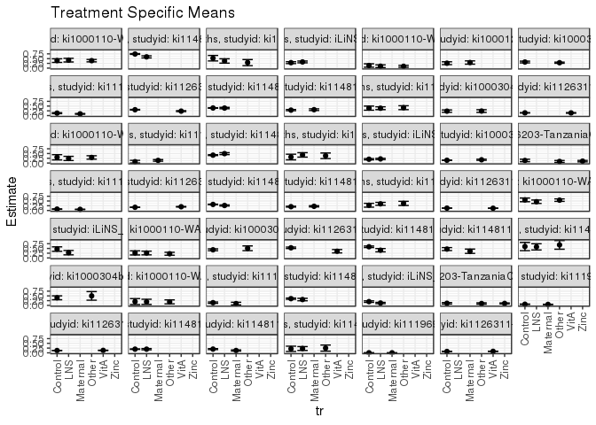

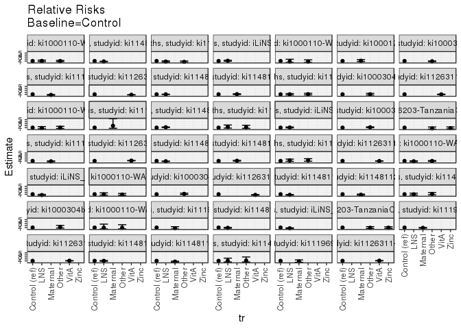

[figure not shown]

[figure not shown]

## Results Table

### Parameter: TSM

| mwtkg | agecat | studyid | country | intervention_level | baseline_level | estimate | ci_lower | ci_upper |
| --- | --- | --- | --- | --- | --- | --- | --- | --- |
| >=57.5 | Birth | ki1119695-PROBIT | BELARUS | Control | NA | 0.0024034 | 0.0009180 | 0.0038887 |
| >=57.5 | Birth | ki1119695-PROBIT | BELARUS | Maternal | NA | 0.0016994 | 0.0009757 | 0.0024231 |
| >=57.5 | Birth | ki1126311-ZVITAMBO | ZIMBABWE | Control | NA | 0.0735493 | 0.0702438 | 0.0768547 |
| >=57.5 | Birth | ki1126311-ZVITAMBO | ZIMBABWE | VitA | NA | 0.0799643 | 0.0739945 | 0.0859340 |
| >=57.5 | 6 months | iLiNS_DYADM_LNS | MALAWI | Control | NA | 0.1979167 | 0.1579620 | 0.2378713 |
| >=57.5 | 6 months | iLiNS_DYADM_LNS | MALAWI | LNS | NA | 0.1250000 | 0.0918353 | 0.1581647 |
| >=57.5 | 6 months | ki1066203-TanzaniaChild2 | TANZANIA, UNITED REPUBLIC OF | Control | NA | 0.1115385 | 0.0732563 | 0.1498206 |
| >=57.5 | 6 months | ki1066203-TanzaniaChild2 | TANZANIA, UNITED REPUBLIC OF | Other | NA | 0.0988142 | 0.0620260 | 0.1356024 |
| >=57.5 | 6 months | ki1066203-TanzaniaChild2 | TANZANIA, UNITED REPUBLIC OF | Zinc | NA | 0.1046931 | 0.0791872 | 0.1301991 |
| >=57.5 | 6 months | ki1119695-PROBIT | BELARUS | Control | NA | 0.0613897 | 0.0508106 | 0.0719688 |
| >=57.5 | 6 months | ki1119695-PROBIT | BELARUS | Maternal | NA | 0.0524220 | 0.0447455 | 0.0600986 |
| >=57.5 | 6 months | ki1126311-ZVITAMBO | ZIMBABWE | Control | NA | 0.1232877 | 0.1182107 | 0.1283646 |
| >=57.5 | 6 months | ki1126311-ZVITAMBO | ZIMBABWE | VitA | NA | 0.1304348 | 0.1214711 | 0.1393985 |
| >=57.5 | 6 months | ki1148112-iLiNS-DOSE | MALAWI | Control | NA | 0.1944444 | 0.1799306 | 0.2089583 |
| >=57.5 | 6 months | ki1148112-iLiNS-DOSE | MALAWI | LNS | NA | 0.1937173 | 0.1603339 | 0.2271007 |
| >=57.5 | 6 months | ki1148112-iLiNS-DYAD-M | MALAWI | Control | NA | 0.1979167 | 0.1713957 | 0.2244376 |
| >=57.5 | 6 months | ki1148112-iLiNS-DYAD-M | MALAWI | Maternal | NA | 0.1243523 | 0.0932084 | 0.1554962 |
| >=57.5 | 6 months | ki1148112-LCNI-5 | MALAWI | Control | NA | 0.2121212 | 0.0720885 | 0.3521539 |
| >=57.5 | 6 months | ki1148112-LCNI-5 | MALAWI | LNS | NA | 0.2272727 | 0.1257696 | 0.3287759 |
| >=57.5 | 6 months | ki1148112-LCNI-5 | MALAWI | Other | NA | 0.2500000 | 0.0889776 | 0.4110224 |
| >=57.5 | 24 months | ki1000110-WASH-Bangladesh | BANGLADESH | Control | NA | 0.2000000 | 0.0424918 | 0.3575082 |
| >=57.5 | 24 months | ki1000110-WASH-Bangladesh | BANGLADESH | LNS | NA | 0.1875000 | 0.0516528 | 0.3233472 |
| >=57.5 | 24 months | ki1000110-WASH-Bangladesh | BANGLADESH | Other | NA | 0.1851852 | 0.0811096 | 0.2892608 |
| >=57.5 | 24 months | ki1119695-PROBIT | BELARUS | Control | NA | 0.1428571 | 0.1059892 | 0.1797251 |
| >=57.5 | 24 months | ki1119695-PROBIT | BELARUS | Maternal | NA | 0.0952381 | 0.0262378 | 0.1642384 |
| >=57.5 | 24 months | ki1148112-iLiNS-DOSE | MALAWI | Control | NA | 0.3548387 | 0.3223071 | 0.3873703 |
| >=57.5 | 24 months | ki1148112-iLiNS-DOSE | MALAWI | LNS | NA | 0.3076923 | 0.2434302 | 0.3719544 |
| <42.5 | Birth | ki1000304b-SAS-CompFeed | INDIA | Control | NA | 0.4000000 | 0.2976738 | 0.5023262 |
| <42.5 | Birth | ki1000304b-SAS-CompFeed | INDIA | Other | NA | 0.5000000 | 0.2743627 | 0.7256373 |
| <42.5 | 6 months | iLiNS_DYADM_LNS | MALAWI | Control | NA | 0.4666667 | 0.3501295 | 0.5832038 |

[output cut: 80 more lines]

### Parameter: E(Y)

| mwtkg | agecat | studyid | country | intervention_level | baseline_level | estimate | ci_lower | ci_upper |
| --- | --- | --- | --- | --- | --- | --- | --- | --- |
| >=57.5 | Birth | ki1119695-PROBIT | BELARUS | NA | NA | 0.0020410 | 0.0003864 | 0.0036957 |
| >=57.5 | Birth | ki1126311-ZVITAMBO | ZIMBABWE | NA | NA | 0.0783689 | 0.0715447 | 0.0851930 |
| >=57.5 | 6 months | iLiNS_DYADM_LNS | MALAWI | NA | NA | 0.1614583 | 0.1092759 | 0.2136407 |
| >=57.5 | 6 months | ki1066203-TanzaniaChild2 | TANZANIA, UNITED REPUBLIC OF | NA | NA | 0.1049672 | 0.0865673 | 0.1233671 |
| >=57.5 | 6 months | ki1119695-PROBIT | BELARUS | NA | NA | 0.0568689 | 0.0433967 | 0.0703411 |
| >=57.5 | 6 months | ki1126311-ZVITAMBO | ZIMBABWE | NA | NA | 0.1286348 | 0.1183327 | 0.1389369 |
| >=57.5 | 6 months | ki1148112-iLiNS-DOSE | MALAWI | NA | NA | 0.1938326 | 0.1574306 | 0.2302346 |
| >=57.5 | 6 months | ki1148112-iLiNS-DYAD-M | MALAWI | NA | NA | 0.1487889 | 0.1076876 | 0.1898902 |
| >=57.5 | 6 months | ki1148112-LCNI-5 | MALAWI | NA | NA | 0.2283465 | 0.1550520 | 0.3016409 |
| >=57.5 | 24 months | ki1000110-WASH-Bangladesh | BANGLADESH | NA | NA | 0.1891892 | 0.1159979 | 0.2623805 |
| >=57.5 | 24 months | ki1119695-PROBIT | BELARUS | NA | NA | 0.1159664 | 0.0389195 | 0.1930133 |
| >=57.5 | 24 months | ki1148112-iLiNS-DOSE | MALAWI | NA | NA | 0.3167702 | 0.2446854 | 0.3888550 |
| <42.5 | Birth | ki1000304b-SAS-CompFeed | INDIA | NA | NA | 0.4333333 | 0.1904126 | 0.6762541 |
| <42.5 | 6 months | iLiNS_DYADM_LNS | MALAWI | NA | NA | 0.3636364 | 0.1969656 | 0.5303071 |
| <42.5 | 6 months | ki1000110-WASH-Bangladesh | BANGLADESH | NA | NA | 0.2431373 | 0.1903820 | 0.2958925 |
| <42.5 | 6 months | ki1000304b-SAS-CompFeed | INDIA | NA | NA | 0.4715447 | 0.3331095 | 0.6099799 |
| <42.5 | 6 months | ki1126311-ZVITAMBO | ZIMBABWE | NA | NA | 0.3814433 | 0.2842766 | 0.4786099 |
| <42.5 | 6 months | ki1148112-iLiNS-DOSE | MALAWI | NA | NA | 0.4368932 | 0.3406365 | 0.5331499 |
| <42.5 | 6 months | ki1148112-iLiNS-DYAD-M | MALAWI | NA | NA | 0.3877551 | 0.2499171 | 0.5255931 |
| <42.5 | 6 months | ki1148112-LCNI-5 | MALAWI | NA | NA | 0.6111111 | 0.4977167 | 0.7245056 |
| <42.5 | 24 months | ki1000110-WASH-Bangladesh | BANGLADESH | NA | NA | 0.5259594 | 0.4794092 | 0.5725095 |
| [42.5-50) | Birth | ki1000304b-SAS-CompFeed | INDIA | NA | NA | 0.2361111 | 0.1428378 | 0.3293844 |
| [42.5-50) | Birth | ki1126311-ZVITAMBO | ZIMBABWE | NA | NA | 0.1404899 | 0.1222023 | 0.1587776 |
| [42.5-50) | 6 months | iLiNS_DYADM_LNS | MALAWI | NA | NA | 0.3050847 | 0.2370598 | 0.3731096 |
| [42.5-50) | 6 months | ki1000110-WASH-Bangladesh | BANGLADESH | NA | NA | 0.1071429 | 0.0688794 | 0.1454063 |
| [42.5-50) | 6 months | ki1000125-AgaKhanUniv | PAKISTAN | NA | NA | 0.2786885 | 0.1652414 | 0.3921356 |
| [42.5-50) | 6 months | ki1000304b-SAS-CompFeed | INDIA | NA | NA | 0.3024911 | 0.2458460 | 0.3591362 |
| [42.5-50) | 6 months | ki1119695-PROBIT | BELARUS | NA | NA | 0.1090535 | 0.0741104 | 0.1439966 |
| [42.5-50) | 6 months | ki1126311-ZVITAMBO | ZIMBABWE | NA | NA | 0.2524807 | 0.2241922 | 0.2807692 |
| [42.5-50) | 6 months | ki1148112-iLiNS-DOSE | MALAWI | NA | NA | 0.3966942 | 0.3576797 | 0.4357087 |
| [42.5-50) | 6 months | ki1148112-iLiNS-DYAD-M | MALAWI | NA | NA | 0.3029197 | 0.2484102 | 0.3574292 |
| [42.5-50) | 6 months | ki1148112-LCNI-5 | MALAWI | NA | NA | 0.3963964 | 0.3437802 | 0.4490126 |
| [42.5-50) | 24 months | ki1000110-WASH-Bangladesh | BANGLADESH | NA | NA | 0.3995381 | 0.3533502 | 0.4457260 |
| [42.5-50) | 24 months | ki1148112-iLiNS-DOSE | MALAWI | NA | NA | 0.6166008 | 0.5565698 | 0.6766318 |
| [42.5-50) | 24 months | ki1148112-LCNI-5 | MALAWI | NA | NA | 0.4041096 | 0.3242372 | 0.4839820 |
| [50-57.5) | Birth | ki1126311-ZVITAMBO | ZIMBABWE | NA | NA | 0.1198170 | 0.1090521 | 0.1305818 |
| [50-57.5) | 6 months | iLiNS_DYADM_LNS | MALAWI | NA | NA | 0.2078853 | 0.1601838 | 0.2555868 |
| [50-57.5) | 6 months | ki1000304b-SAS-CompFeed | INDIA | NA | NA | 0.1585366 | 0.1268738 | 0.1901994 |
| [50-57.5) | 6 months | ki1066203-TanzaniaChild2 | TANZANIA, UNITED REPUBLIC OF | NA | NA | 0.1043084 | 0.0757482 | 0.1328685 |
| [50-57.5) | 6 months | ki1119695-PROBIT | BELARUS | NA | NA | 0.0658049 | 0.0495959 | 0.0820139 |
| [50-57.5) | 6 months | ki1126311-ZVITAMBO | ZIMBABWE | NA | NA | 0.1896698 | 0.1738562 | 0.2054834 |
| [50-57.5) | 6 months | ki1148112-iLiNS-DOSE | MALAWI | NA | NA | 0.2733246 | 0.2416398 | 0.3050094 |
| [50-57.5) | 6 months | ki1148112-iLiNS-DYAD-M | MALAWI | NA | NA | 0.2130751 | 0.1735354 | 0.2526147 |
| [50-57.5) | 6 months | ki1148112-LCNI-5 | MALAWI | NA | NA | 0.3377049 | 0.2845424 | 0.3908675 |
| [50-57.5) | 24 months | ki1000110-WASH-Bangladesh | BANGLADESH | NA | NA | 0.2800000 | 0.2176169 | 0.3423831 |
| [50-57.5) | 24 months | ki1119695-PROBIT | BELARUS | NA | NA | 0.1057692 | 0.0249832 | 0.1865553 |
| [50-57.5) | 24 months | ki1148112-iLiNS-DOSE | MALAWI | NA | NA | 0.4810127 | 0.4258368 | 0.5361886 |
| [50-57.5) | 24 months | ki1148112-LCNI-5 | MALAWI | NA | NA | 0.3866667 | 0.3084730 | 0.4648603 |

### Parameter: RR

| mwtkg | agecat | studyid | country | intervention_level | baseline_level | estimate | ci_lower | ci_upper |
| --- | --- | --- | --- | --- | --- | --- | --- | --- |
| >=57.5 | Birth | ki1119695-PROBIT | BELARUS | Control | Control | 1.0000000 | 1.0000000 | 1.0000000 |
| >=57.5 | Birth | ki1119695-PROBIT | BELARUS | Maternal | Control | 0.7070903 | 0.3336798 | 1.4983723 |
| >=57.5 | Birth | ki1126311-ZVITAMBO | ZIMBABWE | Control | Control | 1.0000000 | 1.0000000 | 1.0000000 |
| >=57.5 | Birth | ki1126311-ZVITAMBO | ZIMBABWE | VitA | Control | 1.0872205 | 0.9964916 | 1.1862101 |
| >=57.5 | 6 months | iLiNS_DYADM_LNS | MALAWI | Control | Control | 1.0000000 | 1.0000000 | 1.0000000 |
| >=57.5 | 6 months | iLiNS_DYADM_LNS | MALAWI | LNS | Control | 0.6315789 | 0.4525216 | 0.8814871 |
| >=57.5 | 6 months | ki1066203-TanzaniaChild2 | TANZANIA, UNITED REPUBLIC OF | Control | Control | 1.0000000 | 1.0000000 | 1.0000000 |
| >=57.5 | 6 months | ki1066203-TanzaniaChild2 | TANZANIA, UNITED REPUBLIC OF | Other | Control | 0.8859207 | 0.5339294 | 1.4699611 |
| >=57.5 | 6 months | ki1066203-TanzaniaChild2 | TANZANIA, UNITED REPUBLIC OF | Zinc | Control | 0.9386282 | 0.6161704 | 1.4298363 |
| >=57.5 | 6 months | ki1119695-PROBIT | BELARUS | Control | Control | 1.0000000 | 1.0000000 | 1.0000000 |
| >=57.5 | 6 months | ki1119695-PROBIT | BELARUS | Maternal | Control | 0.8539222 | 0.6819649 | 1.0692385 |
| >=57.5 | 6 months | ki1126311-ZVITAMBO | ZIMBABWE | Control | Control | 1.0000000 | 1.0000000 | 1.0000000 |
| >=57.5 | 6 months | ki1126311-ZVITAMBO | ZIMBABWE | VitA | Control | 1.0579710 | 0.9765177 | 1.1462185 |
| >=57.5 | 6 months | ki1148112-iLiNS-DOSE | MALAWI | Control | Control | 1.0000000 | 1.0000000 | 1.0000000 |
| >=57.5 | 6 months | ki1148112-iLiNS-DOSE | MALAWI | LNS | Control | 0.9962603 | 0.8256799 | 1.2020815 |
| >=57.5 | 6 months | ki1148112-iLiNS-DYAD-M | MALAWI | Control | Control | 1.0000000 | 1.0000000 | 1.0000000 |
| >=57.5 | 6 months | ki1148112-iLiNS-DYAD-M | MALAWI | Maternal | Control | 0.6283065 | 0.4729475 | 0.8346996 |
| >=57.5 | 6 months | ki1148112-LCNI-5 | MALAWI | Control | Control | 1.0000000 | 1.0000000 | 1.0000000 |
| >=57.5 | 6 months | ki1148112-LCNI-5 | MALAWI | LNS | Control | 1.0714286 | 0.4828526 | 2.3774525 |
| >=57.5 | 6 months | ki1148112-LCNI-5 | MALAWI | Other | Control | 1.1785714 | 0.4685996 | 2.9642161 |
| >=57.5 | 24 months | ki1000110-WASH-Bangladesh | BANGLADESH | Control | Control | 1.0000000 | 1.0000000 | 1.0000000 |
| >=57.5 | 24 months | ki1000110-WASH-Bangladesh | BANGLADESH | LNS | Control | 0.9375000 | 0.3215333 | 2.7334845 |
| >=57.5 | 24 months | ki1000110-WASH-Bangladesh | BANGLADESH | Other | Control | 0.9259259 | 0.3518781 | 2.4364651 |
| >=57.5 | 24 months | ki1119695-PROBIT | BELARUS | Control | Control | 1.0000000 | 1.0000000 | 1.0000000 |
| >=57.5 | 24 months | ki1119695-PROBIT | BELARUS | Maternal | Control | 0.6666667 | 0.3081533 | 1.4422836 |
| >=57.5 | 24 months | ki1148112-iLiNS-DOSE | MALAWI | Control | Control | 1.0000000 | 1.0000000 | 1.0000000 |
| >=57.5 | 24 months | ki1148112-iLiNS-DOSE | MALAWI | LNS | Control | 0.8671329 | 0.6902846 | 1.0892891 |
| <42.5 | Birth | ki1000304b-SAS-CompFeed | INDIA | Control | Control | 1.0000000 | 1.0000000 | 1.0000000 |
| <42.5 | Birth | ki1000304b-SAS-CompFeed | INDIA | Other | Control | 1.2500000 | 0.7550854 | 2.0693025 |
| <42.5 | 6 months | iLiNS_DYADM_LNS | MALAWI | Control | Control | 1.0000000 | 1.0000000 | 1.0000000 |

[output cut: 80 more lines]

### Parameter: PAR

| mwtkg | agecat | studyid | country | intervention_level | baseline_level | estimate | ci_lower | ci_upper |
| --- | --- | --- | --- | --- | --- | --- | --- | --- |
| >=57.5 | Birth | ki1119695-PROBIT | BELARUS | Control | NA | -0.0003624 | -0.0010886 | 0.0003639 |
| >=57.5 | Birth | ki1126311-ZVITAMBO | ZIMBABWE | Control | NA | 0.0048196 | -0.0011506 | 0.0107897 |
| >=57.5 | 6 months | iLiNS_DYADM_LNS | MALAWI | Control | NA | -0.0364583 | -0.0700236 | -0.0028931 |
| >=57.5 | 6 months | ki1066203-TanzaniaChild2 | TANZANIA, UNITED REPUBLIC OF | Control | NA | -0.0065713 | -0.0395843 | 0.0264418 |
| >=57.5 | 6 months | ki1119695-PROBIT | BELARUS | Control | NA | -0.0045208 | -0.0125375 | 0.0034959 |
| >=57.5 | 6 months | ki1126311-ZVITAMBO | ZIMBABWE | Control | NA | 0.0053471 | -0.0036171 | 0.0143114 |
| >=57.5 | 6 months | ki1148112-iLiNS-DOSE | MALAWI | Control | NA | -0.0006118 | -0.0339953 | 0.0327716 |
| >=57.5 | 6 months | ki1148112-iLiNS-DYAD-M | MALAWI | Control | NA | -0.0491277 | -0.0805277 | -0.0177278 |
| >=57.5 | 6 months | ki1148112-LCNI-5 | MALAWI | Control | NA | 0.0162252 | -0.1053916 | 0.1378421 |
| >=57.5 | 24 months | ki1000110-WASH-Bangladesh | BANGLADESH | Control | NA | -0.0108108 | -0.1486174 | 0.1269958 |
| >=57.5 | 24 months | ki1119695-PROBIT | BELARUS | Control | NA | -0.0268908 | -0.0946883 | 0.0409068 |
| >=57.5 | 24 months | ki1148112-iLiNS-DOSE | MALAWI | Control | NA | -0.0380685 | -0.1023951 | 0.0262581 |
| <42.5 | Birth | ki1000304b-SAS-CompFeed | INDIA | Control | NA | 0.0333333 | -0.1837826 | 0.2504493 |
| <42.5 | 6 months | iLiNS_DYADM_LNS | MALAWI | Control | NA | -0.1030303 | -0.2221866 | 0.0161260 |
| <42.5 | 6 months | ki1000110-WASH-Bangladesh | BANGLADESH | Control | NA | -0.0224877 | -0.1154253 | 0.0704498 |
| <42.5 | 6 months | ki1000304b-SAS-CompFeed | INDIA | Control | NA | 0.0429733 | -0.0856094 | 0.1715560 |
| <42.5 | 6 months | ki1126311-ZVITAMBO | ZIMBABWE | Control | NA | -0.1518900 | -0.2407790 | -0.0630010 |
| <42.5 | 6 months | ki1148112-iLiNS-DOSE | MALAWI | Control | NA | -0.1513421 | -0.2394316 | -0.0632526 |
| <42.5 | 6 months | ki1148112-iLiNS-DYAD-M | MALAWI | Control | NA | -0.0789116 | -0.1924974 | 0.0346743 |
| <42.5 | 6 months | ki1148112-LCNI-5 | MALAWI | Control | NA | 0.0111111 | -0.1722864 | 0.1945086 |
| <42.5 | 24 months | ki1000110-WASH-Bangladesh | BANGLADESH | Control | NA | -0.0328642 | -0.1176436 | 0.0519153 |
| [42.5-50) | Birth | ki1000304b-SAS-CompFeed | INDIA | Control | NA | 0.0027778 | -0.0671421 | 0.0726976 |
| [42.5-50) | Birth | ki1126311-ZVITAMBO | ZIMBABWE | Control | NA | -0.0027849 | -0.0186176 | 0.0130477 |
| [42.5-50) | 6 months | iLiNS_DYADM_LNS | MALAWI | Control | NA | 0.0178507 | -0.0296283 | 0.0653298 |
| [42.5-50) | 6 months | ki1000110-WASH-Bangladesh | BANGLADESH | Control | NA | -0.0307882 | -0.1064931 | 0.0449167 |
| [42.5-50) | 6 months | ki1000125-AgaKhanUniv | PAKISTAN | Control | NA | 0.0194293 | -0.0667565 | 0.1056150 |
| [42.5-50) | 6 months | ki1000304b-SAS-CompFeed | INDIA | Control | NA | -0.0186768 | -0.0522188 | 0.0148652 |
| [42.5-50) | 6 months | ki1119695-PROBIT | BELARUS | Control | NA | -0.0190457 | -0.0420915 | 0.0040002 |
| [42.5-50) | 6 months | ki1126311-ZVITAMBO | ZIMBABWE | Control | NA | -0.0555550 | -0.0795766 | -0.0315334 |
| [42.5-50) | 6 months | ki1148112-iLiNS-DOSE | MALAWI | Control | NA | -0.0033058 | -0.0391171 | 0.0325055 |
| [42.5-50) | 6 months | ki1148112-iLiNS-DYAD-M | MALAWI | Control | NA | 0.0156857 | -0.0288449 | 0.0602162 |
| [42.5-50) | 6 months | ki1148112-LCNI-5 | MALAWI | Control | NA | 0.0039913 | -0.0902400 | 0.0982227 |
| [42.5-50) | 24 months | ki1000110-WASH-Bangladesh | BANGLADESH | Control | NA | 0.0034985 | -0.0801553 | 0.0871523 |
| [42.5-50) | 24 months | ki1148112-iLiNS-DOSE | MALAWI | Control | NA | -0.1269890 | -0.1831645 | -0.0708134 |
| [42.5-50) | 24 months | ki1148112-LCNI-5 | MALAWI | Control | NA | -0.1176295 | -0.2365412 | 0.0012821 |
| [50-57.5) | Birth | ki1126311-ZVITAMBO | ZIMBABWE | Control | NA | -0.0048916 | -0.0141897 | 0.0044064 |
| [50-57.5) | 6 months | iLiNS_DYADM_LNS | MALAWI | Control | NA | 0.0078853 | -0.0256764 | 0.0414470 |
| [50-57.5) | 6 months | ki1000304b-SAS-CompFeed | INDIA | Control | NA | 0.0121951 | -0.0182435 | 0.0426338 |
| [50-57.5) | 6 months | ki1066203-TanzaniaChild2 | TANZANIA, UNITED REPUBLIC OF | Control | NA | -0.0308267 | -0.0840137 | 0.0223602 |
| [50-57.5) | 6 months | ki1119695-PROBIT | BELARUS | Control | NA | -0.0068513 | -0.0180856 | 0.0043829 |
| [50-57.5) | 6 months | ki1126311-ZVITAMBO | ZIMBABWE | Control | NA | 0.0215437 | 0.0075773 | 0.0355100 |
| [50-57.5) | 6 months | ki1148112-iLiNS-DOSE | MALAWI | Control | NA | -0.0451939 | -0.0736420 | -0.0167459 |
| [50-57.5) | 6 months | ki1148112-iLiNS-DYAD-M | MALAWI | Control | NA | 0.0130751 | -0.0191680 | 0.0453181 |
| [50-57.5) | 6 months | ki1148112-LCNI-5 | MALAWI | Control | NA | 0.0613891 | -0.0275669 | 0.1503452 |
| [50-57.5) | 24 months | ki1000110-WASH-Bangladesh | BANGLADESH | Control | NA | -0.0223256 | -0.1435125 | 0.0988613 |
| [50-57.5) | 24 months | ki1119695-PROBIT | BELARUS | Control | NA | 0.0350622 | -0.0105682 | 0.0806925 |
| [50-57.5) | 24 months | ki1148112-iLiNS-DOSE | MALAWI | Control | NA | 0.0659183 | 0.0154428 | 0.1163939 |
| [50-57.5) | 24 months | ki1148112-LCNI-5 | MALAWI | Control | NA | 0.0708772 | -0.0593616 | 0.2011160 |

### Parameter: PAF

| mwtkg | agecat | studyid | country | intervention_level | baseline_level | estimate | ci_lower | ci_upper |
| --- | --- | --- | --- | --- | --- | --- | --- | --- |
| >=57.5 | Birth | ki1119695-PROBIT | BELARUS | Control | NA | -0.1775343 | -0.7091053 | 0.1887060 |
| >=57.5 | Birth | ki1126311-ZVITAMBO | ZIMBABWE | Control | NA | 0.0614989 | -0.0128408 | 0.1303822 |
| >=57.5 | 6 months | iLiNS_DYADM_LNS | MALAWI | Control | NA | -0.2258065 | -0.5165322 | 0.0091859 |
| >=57.5 | 6 months | ki1066203-TanzaniaChild2 | TANZANIA, UNITED REPUBLIC OF | Control | NA | -0.0626030 | -0.4284149 | 0.2095258 |
| >=57.5 | 6 months | ki1119695-PROBIT | BELARUS | Control | NA | -0.0794958 | -0.2442749 | 0.0634617 |
| >=57.5 | 6 months | ki1126311-ZVITAMBO | ZIMBABWE | Control | NA | 0.0415683 | -0.0276262 | 0.1061036 |
| >=57.5 | 6 months | ki1148112-iLiNS-DOSE | MALAWI | Control | NA | -0.0031566 | -0.1916988 | 0.1555558 |
| >=57.5 | 6 months | ki1148112-iLiNS-DYAD-M | MALAWI | Control | NA | -0.3301841 | -0.6502758 | -0.0721782 |
| >=57.5 | 6 months | ki1148112-LCNI-5 | MALAWI | Control | NA | 0.0710554 | -0.6477217 | 0.4762841 |
| >=57.5 | 24 months | ki1000110-WASH-Bangladesh | BANGLADESH | Control | NA | -0.0571429 | -1.1052664 | 0.4691641 |
| >=57.5 | 24 months | ki1119695-PROBIT | BELARUS | Control | NA | -0.2318840 | -1.2166520 | 0.3153917 |
| >=57.5 | 24 months | ki1148112-iLiNS-DOSE | MALAWI | Control | NA | -0.1201771 | -0.3728045 | 0.0859611 |
| <42.5 | Birth | ki1000304b-SAS-CompFeed | INDIA | Control | NA | 0.0769231 | -0.5231190 | 0.4405749 |
| <42.5 | 6 months | iLiNS_DYADM_LNS | MALAWI | Control | NA | -0.2833333 | -0.7944393 | 0.0821955 |
| <42.5 | 6 months | ki1000110-WASH-Bangladesh | BANGLADESH | Control | NA | -0.0924899 | -0.5499121 | 0.2299342 |
| <42.5 | 6 months | ki1000304b-SAS-CompFeed | INDIA | Control | NA | 0.0911330 | -0.1938009 | 0.3080595 |
| <42.5 | 6 months | ki1126311-ZVITAMBO | ZIMBABWE | Control | NA | -0.3981982 | -0.7683600 | -0.1055205 |
| <42.5 | 6 months | ki1148112-iLiNS-DOSE | MALAWI | Control | NA | -0.3464052 | -0.6493083 | -0.0991317 |
| <42.5 | 6 months | ki1148112-iLiNS-DYAD-M | MALAWI | Control | NA | -0.2035088 | -0.6163102 | 0.1038642 |
| <42.5 | 6 months | ki1148112-LCNI-5 | MALAWI | Control | NA | 0.0181818 | -0.3328955 | 0.2767873 |
| <42.5 | 24 months | ki1000110-WASH-Bangladesh | BANGLADESH | Control | NA | -0.0624842 | -0.2366937 | 0.0871849 |
| [42.5-50) | Birth | ki1000304b-SAS-CompFeed | INDIA | Control | NA | 0.0117647 | -0.3288545 | 0.2650746 |
| [42.5-50) | Birth | ki1126311-ZVITAMBO | ZIMBABWE | Control | NA | -0.0198231 | -0.1414873 | 0.0888738 |
| [42.5-50) | 6 months | iLiNS_DYADM_LNS | MALAWI | Control | NA | 0.0585106 | -0.1003734 | 0.1944533 |
| [42.5-50) | 6 months | ki1000110-WASH-Bangladesh | BANGLADESH | Control | NA | -0.2873563 | -1.2198428 | 0.2534218 |
| [42.5-50) | 6 months | ki1000125-AgaKhanUniv | PAKISTAN | Control | NA | 0.0697168 | -0.2682325 | 0.3176118 |
| [42.5-50) | 6 months | ki1000304b-SAS-CompFeed | INDIA | Control | NA | -0.0617432 | -0.1866953 | 0.0500521 |
| [42.5-50) | 6 months | ki1119695-PROBIT | BELARUS | Control | NA | -0.1746453 | -0.4552222 | 0.0518345 |
| [42.5-50) | 6 months | ki1126311-ZVITAMBO | ZIMBABWE | Control | NA | -0.2200367 | -0.3426159 | -0.1086487 |
| [42.5-50) | 6 months | ki1148112-iLiNS-DOSE | MALAWI | Control | NA | -0.0083333 | -0.1035957 | 0.0787060 |
| [42.5-50) | 6 months | ki1148112-iLiNS-DYAD-M | MALAWI | Control | NA | 0.0517816 | -0.0984975 | 0.1815018 |
| [42.5-50) | 6 months | ki1148112-LCNI-5 | MALAWI | Control | NA | 0.0100690 | -0.2586239 | 0.2214010 |
| [42.5-50) | 24 months | ki1000110-WASH-Bangladesh | BANGLADESH | Control | NA | 0.0087564 | -0.2243764 | 0.1974985 |
| [42.5-50) | 24 months | ki1148112-iLiNS-DOSE | MALAWI | Control | NA | -0.2059500 | -0.3212275 | -0.1007305 |
| [42.5-50) | 24 months | ki1148112-LCNI-5 | MALAWI | Control | NA | -0.2910833 | -0.6268482 | -0.0246168 |
| [50-57.5) | Birth | ki1126311-ZVITAMBO | ZIMBABWE | Control | NA | -0.0408259 | -0.1248357 | 0.0369095 |
| [50-57.5) | 6 months | iLiNS_DYADM_LNS | MALAWI | Control | NA | 0.0379310 | -0.1307739 | 0.1814661 |
| [50-57.5) | 6 months | ki1000304b-SAS-CompFeed | INDIA | Control | NA | 0.0769231 | -0.1184617 | 0.2381760 |
| [50-57.5) | 6 months | ki1066203-TanzaniaChild2 | TANZANIA, UNITED REPUBLIC OF | Control | NA | -0.2955347 | -0.9136861 | 0.1229439 |
| [50-57.5) | 6 months | ki1119695-PROBIT | BELARUS | Control | NA | -0.1041155 | -0.3119298 | 0.0707802 |
| [50-57.5) | 6 months | ki1126311-ZVITAMBO | ZIMBABWE | Control | NA | 0.1135852 | 0.0456883 | 0.1766513 |
| [50-57.5) | 6 months | ki1148112-iLiNS-DOSE | MALAWI | Control | NA | -0.1653490 | -0.2935027 | -0.0498921 |
| [50-57.5) | 6 months | ki1148112-iLiNS-DYAD-M | MALAWI | Control | NA | 0.0613636 | -0.0921610 | 0.1933074 |
| [50-57.5) | 6 months | ki1148112-LCNI-5 | MALAWI | Control | NA | 0.1817833 | -0.1286174 | 0.4068154 |
| [50-57.5) | 24 months | ki1000110-WASH-Bangladesh | BANGLADESH | Control | NA | -0.0797342 | -0.6120551 | 0.2768076 |
| [50-57.5) | 24 months | ki1119695-PROBIT | BELARUS | Control | NA | 0.3314968 | -0.1652739 | 0.6164880 |
| [50-57.5) | 24 months | ki1148112-iLiNS-DOSE | MALAWI | Control | NA | 0.1370407 | 0.0413164 | 0.2232070 |
| [50-57.5) | 24 months | ki1148112-LCNI-5 | MALAWI | Control | NA | 0.1833031 | -0.2336903 | 0.4593507 |